# R语言及其在社会分析中的应用：垃圾邮件例子与作业

Xiangyu Channg

04/07/2018

## 读入数据

```r
library(kernlab)
data(spam)
str(spam)
```

```
## 'data.frame':    4601 obs. of  58 variables:
##  $ make             : num  0 0.21 0.06 0 0 0 0 0 0.15 0.06 ...
##  $ address          : num  0.64 0.28 0 0 0 0 0 0 0 0.12 ...
##  $ all              : num  0.64 0.5 0.71 0 0 0 0 0 0.46 0.77 ...
##  $ num3d            : num  0 0 0 0 0 0 0 0 0 0 ...
##  $ our              : num  0.32 0.14 1.23 0.63 0.63 1.85 1.92 1.88 0.61 0.19 ...
##  $ over             : num  0 0.28 0.19 0 0 0 0 0 0 0.32 ...
##  $ remove           : num  0 0.21 0.19 0.31 0.31 0 0 0 0.3 0.38 ...
##  $ internet         : num  0 0.07 0.12 0.63 0.63 1.85 0 1.88 0 0 ...
##  $ order            : num  0 0 0.64 0.31 0.31 0 0 0 0.92 0.06 ...
##  $ mail             : num  0 0.94 0.25 0.63 0.63 0 0.64 0 0.76 0 ...
##  $ receive          : num  0 0.21 0.38 0.31 0.31 0 0.96 0 0.76 0 ...
##  $ will             : num  0.64 0.79 0.45 0.31 0.31 0 1.28 0 0.92 0.64 ...
##  $ people           : num  0 0.65 0.12 0.31 0.31 0 0 0 0 0.25 ...
##  $ report           : num  0 0.21 0 0 0 0 0 0 0 0 ...
```

[output cut: 44 more lines]

## 探索分析

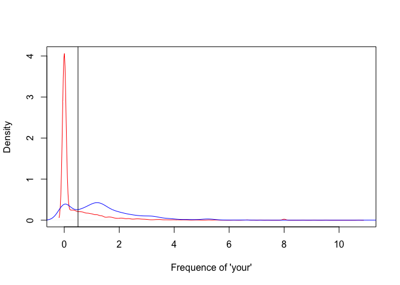

```r
#Basic Plot

plot(density(spam$your[spam$type == "nonspam"]), col = "red", main = "", xlab = "Frequence of 'your'")
lines(density(spam$your[spam$type == "spam"]), col = "blue")
abline(v=0.5, col ="black")
```

## 判定规则

```r
#Prediction Rule
#Variable 'your' is selected as a feature.
prediction <- ifelse(spam$your > 0.5, "spam", "nonspam")

#Corrected Prediciton Rate
table(prediction, spam$type)/dim(spam)[1]
```

```
##
## prediction   nonspam      spam
##    nonspam 0.4590306 0.1017170
##    spam    0.1469246 0.2923278
```

```r
sum(diag(table(prediction, spam$type)/dim(spam)[1]))
```

```
## [1] 0.7513584
```

## 作业

### 作业1：

R语言是数据科学的最主要使用语言之一。它的特点是简单易用，功能强大。R语言有自己的历史和独有的特点。本部分作业是阅读狗熊会**《R与千寻》**栏目的[**初识R语言章节**](https://mp.weixin.qq.com/s?__biz=MzA5MjEyMTYwMg==&mid=2650236942&idx=1&sn=f351a6c569a19bebfde773b32ceb1799&scene=21#wechat_redirect)与[**R的获取与安装**](https://mp.weixin.qq.com/s?__biz=MzA5MjEyMTYwMg==&mid=2650237249&idx=1&sn=14a2a0ed00f2ef4c4c0c003f05097776&scene=21#wechat_redirect)。

[figure not shown]

安装R与RStudio

观看**狗熊会**视频微课中的**R语言入门**视频，并在自己电脑上安装最新的R与Rstudio版本。

### 作业2：学习R Markdown

阅读**狗熊会**人才计划**学习R Markdown**，使用[**R Markdown的语法手册**](https://www.rstudio.com/wp-content/uploads/2015/02/rmarkdown-cheatsheet.pdf)完成如下任务：

- 准备一份去年任何你上过的课程报告。
- 创建一个Rmd文档通过Rstudio。
- 修改 Rmd 模板中作者为你的名字。
- 请修改 Rmd 模板中的第一节的标题为“课程介绍”。并在下面写入这 门课程的介绍
- 请修改 Rmd 模板中的第二节中标题为“报告正文”。
- 在第二节的第一小节写入报告摘要。
- 在第二节的第二小节插入一张与报告相关的图片。
- 在第二节的第三小节插入一张与报告相关的表格。
- 在第二节的第四小节插入如下 R 代码，并运行。 >`data(cars)` >`plot(cars$speed,cars$dist)`
- 生成第三节，标题为“结论”。写入报告结论，并引用某个参考文献。
- 选做题：在第二节的第五小节写一段你的报告中用到的数学公式(用latex语法写)。例如`$$\sum_{i=1}^n \frac{1}{n^2}$$`。效果为

$$\sum_{i=1}^n \frac{1}{n^2}.$$